```python
from IPython.display import Image, display
from matplotlib.pyplot import figure, imshow, axis
from matplotlib.image import imread
```

# Cellular Automata Overview

Cellular automaton follow simple rules yet can exhibit complex behavior. They are prominently featured in A New Kind of Science by Stephen Wolfram and Permutation City by Greg Egan.

Below is rule 90 (b01011010). The top row represents a cell and its left and right neighbors. The bottom row is what the cell's value will be on the next iteration. If we instead used rule b01011011, then a white cell with white neighbors will be black on the next iteration.

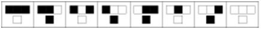

```python
Image('images/example_rule.jpeg')
```

Cellular Automata are broken up into four distinct classes.

- Class 1
  - rules leading to homogenous states, all cells stably ending up with the same value
- Class 2
  - rules leading to stable structures or simple periodic patterns
- Class 3
  - rules leading to seemingly chaotic, non-periodic behavior
- Class 4
  - rules leading to complex patterns and structures propagating locally in the lattice

The four images below represent the four classes. Can you guess which ones belong to which class?

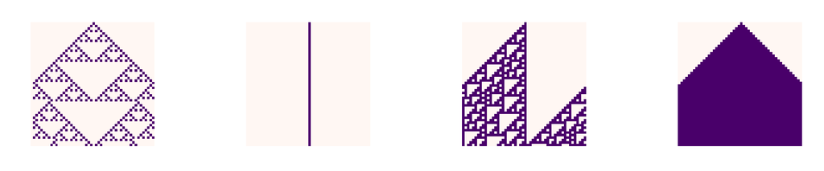

```python
images = ['images/rule_90.png','images/rule_108.png','images/rule_110.png','images/rule_254.png']

fig = figure(figsize = (50,10))
number_of_files = len(images)
for i in range(number_of_files):
    a=fig.add_subplot(1,number_of_files,i+1)
    image = imread(images[i])
    imshow(image)
    axis('off')
```

Now let's treat these cellular automata as "mazes" and apply some popular path-finding algorithms

- Step 1
  - If a cell has value 1, with 30 percent probability, assign it as a red cell
  - If a cell has value 0, mark it as a white cell
- Step 2
  - Pick random cells to be the "start" and "end" of a maze
- Step 3
  - Apply DFS, BFS, or A* search to see if the maze can be solved!

The Below example is rule 254 and a dfs.

[figure not shown]

```python
Image('images/rule_254_dfs.png', width=500, height=500)
# sus
```

## Clone the repo to create your own cellular automata, compare dfs to a*, or just make cool picture!